# **Topic 9 - Basic Plots in R**

Esam Mahdi

2026-05-04

# Introduction to R Graphics

**Why use base R plots?**

- No additional packages needed - they work immediately after installing **R**
- Fast and efficient for exploratory analysis
- Simple syntax that’s easy to learn and remember
- Direct control over plot elements

## The Four Essential Plotting Functions

We’ll explore four fundamental plotting functions in **R**:

| Function | Purpose | Best For |
| --- | --- | --- |
| `plot()` | Scatterplots and generic plotting | Two continuous variables |
| `hist()` | Histograms | Distribution of a single variable |
| `barplot()` | Bar charts | Categorical data comparisons |
| `boxplot()` | Box-and-whisker plots | Distribution spread and outliers |

Let’s create sample data to work with throughout this tutorial:

```r
# Set seed for reproducible results
set.seed(42)

# Create sample datasets with consistent lengths
n <- 150  # Set a common sample size

# Numeric data for histograms and boxplots
normal_data <- rnorm(n, mean = 50, sd = 10)  # Normally distributed
skewed_data <- rexp(n, rate = 0.05)          # Exponential distribution (Right-skewed data)

# Categorical data for barplots
categories <- c("Apple", "Banana", "Cherry", "Date", "Orange")
frequencies <- c(25, 40, 15, 30, 20)

# Two continuous variables for scatterplots (use same n)
height <- rnorm(n, mean = 165, sd = 10)
weight <- height * 0.6 + rnorm(n, mean = 0, sd = 5)  # Correlation with height

# Grouped data for boxplots (create 3 groups of equal size)
group_size <- n / 3  # 150/3 = 50
group_A <- rnorm(group_size, mean = 45, sd = 8)
group_B <- rnorm(group_size, mean = 55, sd = 10)
group_C <- rnorm(group_size, mean = 50, sd = 6)

# Combine into data frame for easy access
df <- data.frame(
  height = height,
  weight = weight,
  group = rep(c("A", "B", "C"), each = group_size),
  value = c(group_A, group_B, group_C)
)

# View first 3 rows
head(df, 3)
```

```
##     height    weight group    value
## 1 147.3541  84.34995     A 43.95475
## 2 161.1146 101.94570     A 39.43582
## 3 158.3074  90.44644     A 42.19918
```

```r
# Check dimensions
dim(df)
```

```
## [1] 150   4
```

# The plot() Function - Scatterplots

The `plot()` function is the workhorse of **R** graphics. It’s a generic function that produces different types of plots depending on what you give it.

## Basic Syntax

```
# Most common usage
plot(x, y)                    # Scatterplot
plot(x)                       # Plot against index (1, 2, 3, ...)
plot(factor)                  # Bar plot for factors
```

## Common Arguments

| Argument | Description | Example | Default |
| --- | --- | --- | --- |
| **`x`** | Vector of x-coordinates | `height` | **Required** |
| **`y`** | Vector of y-coordinates | `weight` | `NULL` |
| `main` | Main title | `"Height vs Weight"` | `NULL` |
| `xlab` | Label for x-axis | `"Height (cm)"` | Variable name |
| `ylab` | Label for y-axis | `"Weight (kg)"` | Variable name |
| `col` | Color of points/lines | `"blue"`, `"#FF5733"` | `"black"` |
| `pch` | Point type (0-25) | `16` (filled circle) | `1` (open circle) |
| `cex` | Point size multiplier | `1.5` (50% larger) | `1` |
| `type` | Type of plot | `"p"` (points), `"l"` (lines), `"b"` (both) | `"p"` |
| `xlim` | Range of x-axis | `c(120, 200)` | Range of data |
| `ylim` | Range of y-axis | `c(70, 120)` | Range of data |

### Examples

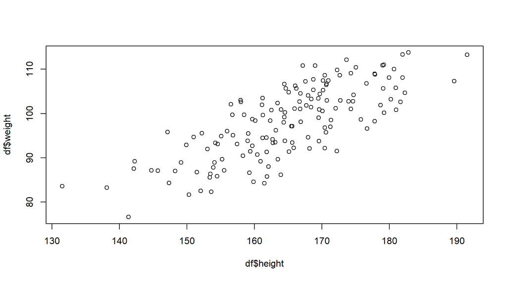

```r
# Basic scatterplot
plot(df$height, df$weight)
```

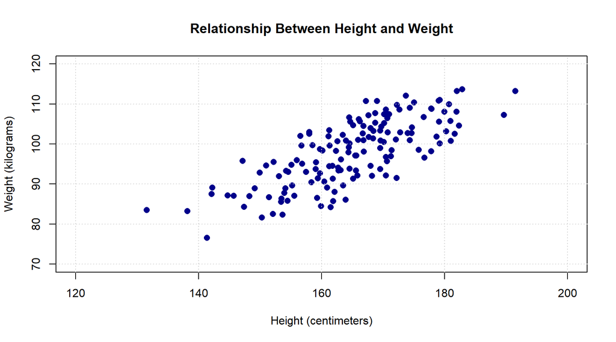

```r
# Enhanced scatterplot with all common arguments
plot(x = df$height,
     y = df$weight,
     main = "Relationship Between Height and Weight",
     xlab = "Height (centimeters)",
     ylab = "Weight (kilograms)",
     col = "darkblue",
     pch = 16,
     cex = 1.2,
     xlim = c(120, 200),
     ylim = c(70, 120))
grid(col = "lightgray", lty = 3)  # Add grid lines
```

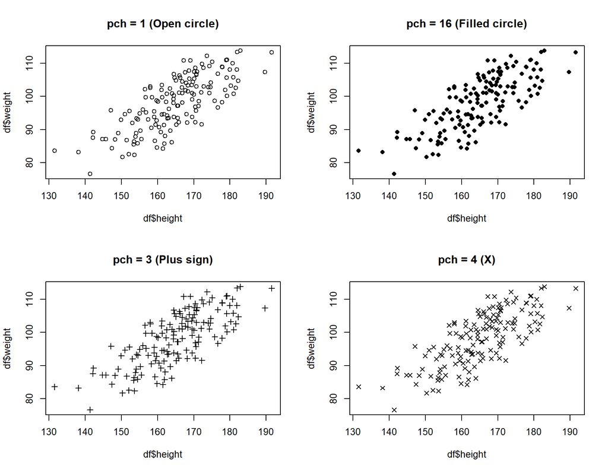

```r
# Different point types (pch values)
par(mfrow = c(2, 2))  # Create 2x2 grid of plots

plot(df$height, df$weight, pch = 1, main = "pch = 1 (Open circle)")
plot(df$height, df$weight, pch = 16, main = "pch = 16 (Filled circle)")
plot(df$height, df$weight, pch = 3, main = "pch = 3 (Plus sign)")
plot(df$height, df$weight, pch = 4, main = "pch = 4 (X)")
```

```r
par(mfrow = c(1, 1))  # Reset to single plot
```

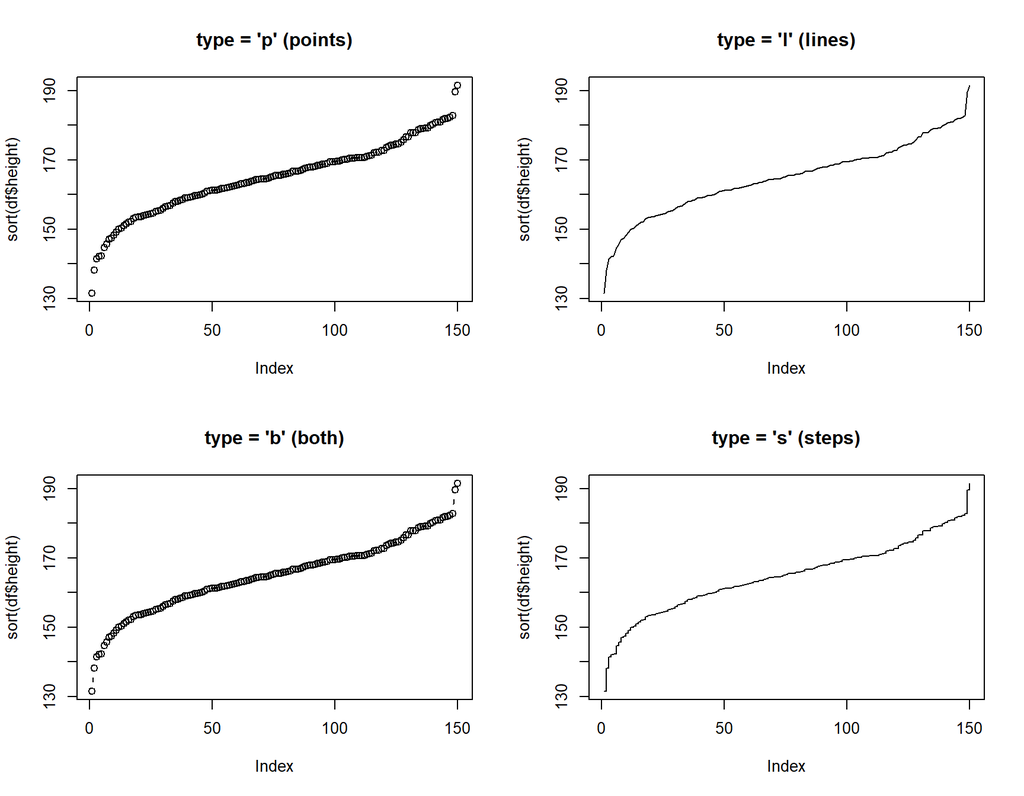

```r
# Different plot types
par(mfrow = c(2, 2))

# Points only (default)
plot(sort(df$height), type = "p", main = "type = 'p' (points)")

# Lines only
plot(sort(df$height), type = "l", main = "type = 'l' (lines)")

# Both points and lines
plot(sort(df$height), type = "b", main = "type = 'b' (both)")

# Stair steps
plot(sort(df$height), type = "s", main = "type = 's' (steps)")
```

```r
par(mfrow = c(1, 1))
```

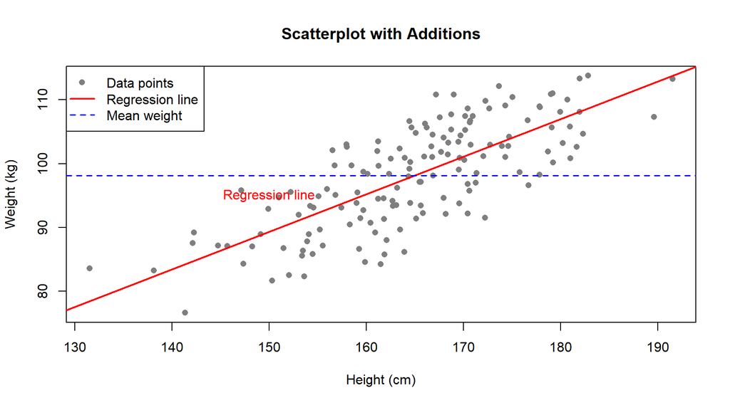

```r
# Adding elements to existing plot
plot(df$height, df$weight,
     main = "Scatterplot with Additions",
     xlab = "Height (cm)",
     ylab = "Weight (kg)",
     col = "gray50",
     pch = 16)

# Add a regression line (linear model)
abline(lm(weight ~ height, data = df), col = "red", lwd = 2)

# Add a horizontal line at mean weight
abline(h = mean(df$weight), col = "blue", lty = 2, lwd = 1.5)

# Add text annotation
text(x = 150, y = 95, labels = "Regression line", col = "red")

# Add legend
legend("topleft",
       legend = c("Data points", "Regression line", "Mean weight"),
       col = c("gray50", "red", "blue"),
       pch = c(16, NA, NA),
       lty = c(NA, 1, 2),
       lwd = c(NA, 2, 1.5))
```

### Quick Reference for `plot()`:

```
# Most common pattern
plot(x = data$variable1, y = data$variable2,
     main = "Title", xlab = "X Label", ylab = "Y Label",
     col = "color", pch = point_type, cex = point_size)
```

# The `hist()` Function - Histograms

**Histograms** show the distribution of a single continuous variable by dividing the data into bins (intervals) and showing the frequency of observations in each bin.

## Basic Syntax

```
hist(x)                       # Basic histogram
hist(x, breaks = n)           # Specify number of bins
```

## Common Arguments

| Argument | Description | Example | Default |
| --- | --- | --- | --- |
| **`x`** | Vector of numeric values | `normal_data` | **Required** |
| `breaks` | Number of bins or bin boundaries | `20`, `seq(0, 100, by = 5)` | `"Sturges"` formula |
| `freq` | Show frequency (TRUE) or density (FALSE) | `TRUE` or `FALSE` | `TRUE` |
| `main` | Main title | `"Distribution of Values"` | `NULL` |
| `xlab` | Label for x-axis | `"Values"` | Variable name |
| `ylab` | Label for y-axis | `"Frequency"` | `"Frequency"` |
| `col` | Color of bars | `"skyblue"` | `NULL` |
| `border` | Color of bar borders | `"white"` | `"black"` |

### Examples

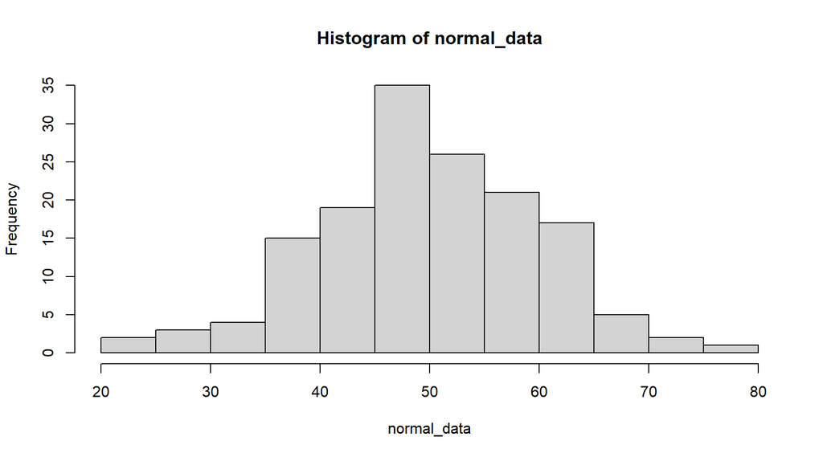

```r
# Basic histogram
hist(normal_data)
```

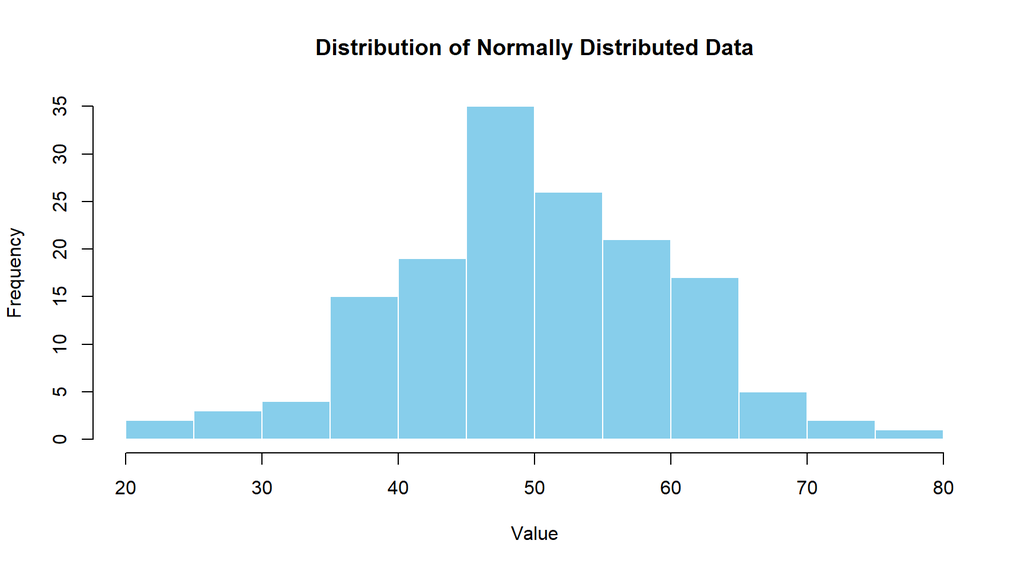

```r
# Enhanced histogram with common arguments
hist(normal_data,
     breaks = 15,
     main = "Distribution of Normally Distributed Data",
     xlab = "Value",
     ylab = "Frequency",
     col = "skyblue",
     border = "white")
```

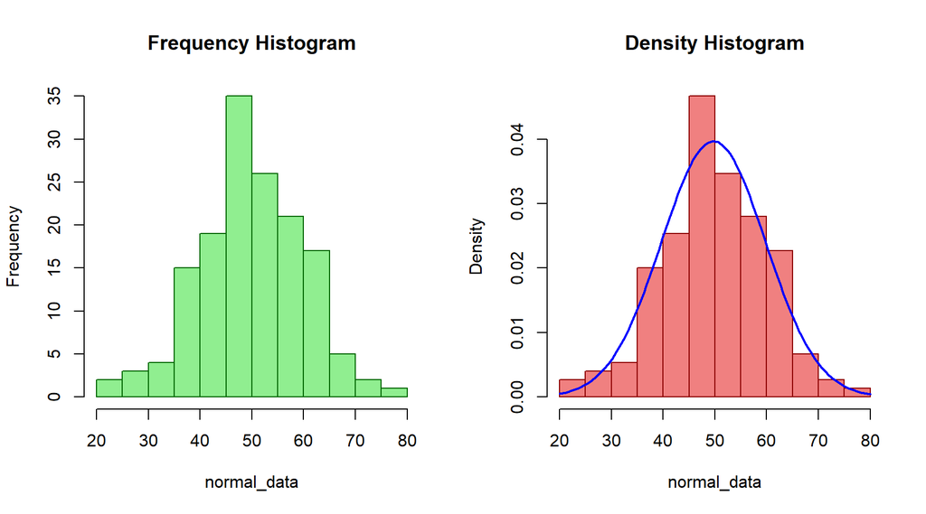

```r
# Comparing frequency vs. density
par(mfrow = c(1, 2))

# Frequency histogram (counts)
hist(normal_data, freq = TRUE,
     main = "Frequency Histogram",
     col = "lightgreen",
     border = "darkgreen")

# Density histogram (area = 1, like probability)
hist(normal_data, freq = FALSE,
     main = "Density Histogram",
     col = "lightcoral",
     border = "darkred")
# Add density curve
curve(dnorm(x, mean = mean(normal_data), sd = sd(normal_data)),
      add = TRUE, col = "blue", lwd = 2)
```

```r
par(mfrow = c(1, 1))
```

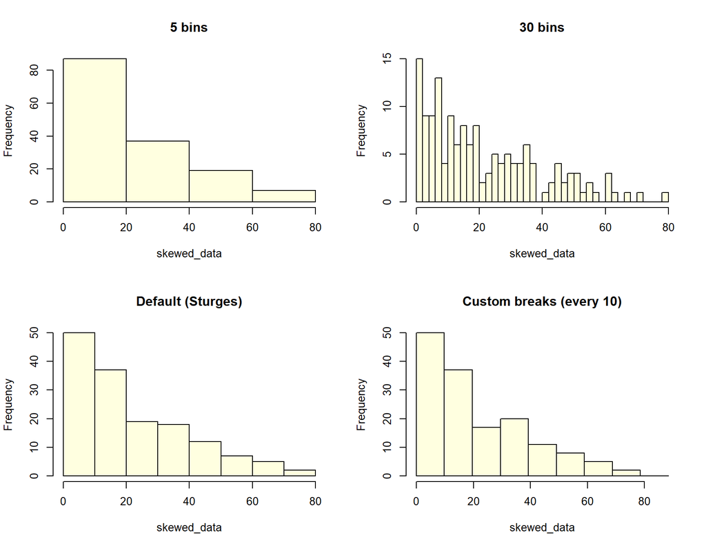

```r
# Different bin specifications
par(mfrow = c(2, 2))

# Few bins (under-smoothing)
hist(skewed_data, breaks = 5,
     main = "5 bins",
     col = "lightyellow")

# Many bins (over-smoothing)
hist(skewed_data, breaks = 30,
     main = "30 bins",
     col = "lightyellow")

# Sturges formula (default)
hist(skewed_data, main = "Default (Sturges)",
     col = "lightyellow")

# Custom break points
hist(skewed_data, breaks = seq(0, max(skewed_data) + 10, length.out = 10),
     main = "Custom breaks (every 10)",
     col = "lightyellow")
```

```r
par(mfrow = c(1, 1))
```

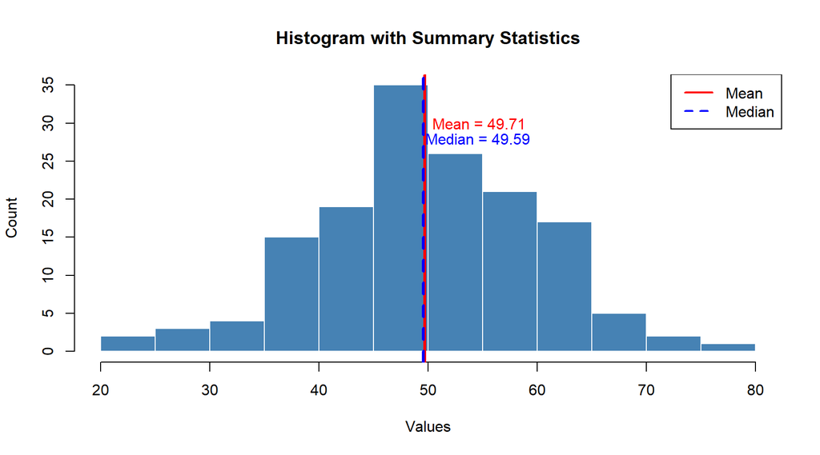

```r
# Histogram with additional features
hist(normal_data,
     breaks = 20,
     main = "Histogram with Summary Statistics",
     xlab = "Values",
     ylab = "Count",
     col = "steelblue",
     border = "white")

# Add mean and median lines
abline(v = mean(normal_data), col = "red", lwd = 3, lty = 1)
abline(v = median(normal_data), col = "blue", lwd = 3, lty = 2)

# Add text for statistics
text(x = mean(normal_data) + 5, y = 30,
     labels = paste("Mean =", round(mean(normal_data), 2)),
     col = "red")
text(x = median(normal_data) + 5, y = 28,
     labels = paste("Median =", round(median(normal_data), 2)),
     col = "blue")

# Add legend
legend("topright",
       legend = c("Mean", "Median"),
       col = c("red", "blue"),
       lty = c(1, 2),
       lwd = 2)
```

### Quick Reference for `hist()`:

```
# Most common pattern
hist(data$variable,
     breaks = number_of_bins,
     main = "Title",
     xlab = "X Label",
     col = "color",
     border = "border_color")
```

# The `barplot()` Function - Bar Charts

**Barplots** display **categorical data** by showing rectangular bars with heights proportional to the values they represent.

## Basic Syntax

```
barplot(height)               # Height is a vector or matrix
barplot(table(factor))        # From a frequency table
```

### Common Arguments

| Argument | Description | Example | Default |
| --- | --- | --- | --- |
| **`height`** | Data values (vector or matrix) | `c(10,20,30)` | **Required** |
| `names.arg` | Bar labels | `c("A","B","C")` | `NULL` |
| `col` | Bar color(s) | `"steelblue"` | `"grey"` |
| `horiz` | Flip to horizontal | `TRUE` | `FALSE` |
| `beside` | Side-by-side (matrices) | `TRUE` | `FALSE` |
| `main` | Title | `"My Plot"` | `NULL` |
| `xlab`/`ylab` | Axis labels | `"Categories"`, `"Counts"` | `NULL` |
| `las` | Rotate labels (2 = vertical) | `2` | `0` |
| `legend.text` | Add legend | `c("A","B")` | `NULL` |

### Examples

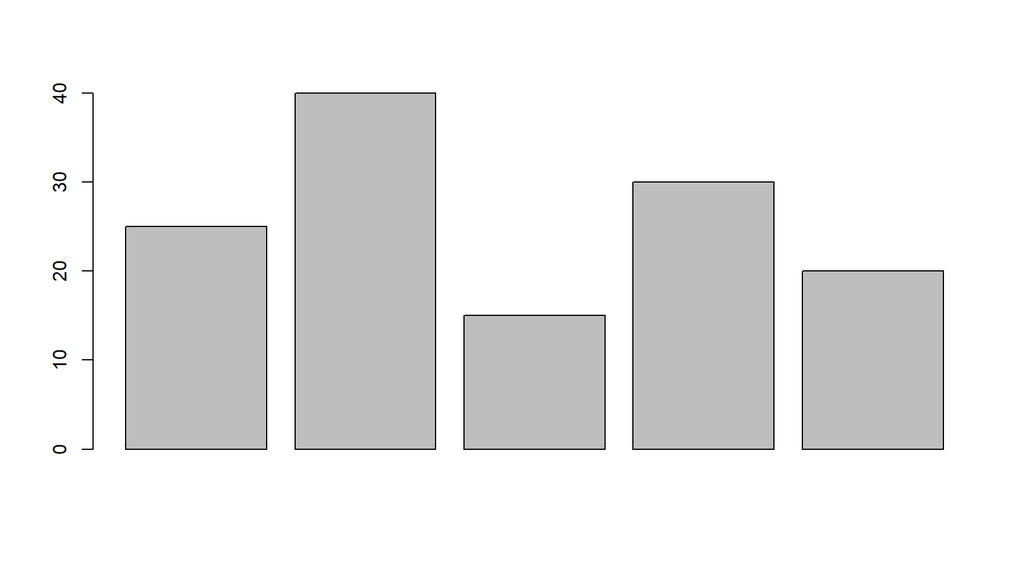

```r
# Basic barplot
barplot(frequencies)
```

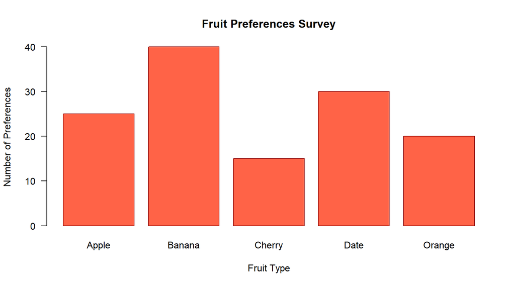

```r
# Enhanced barplot with labels
barplot(height = frequencies,
        names.arg = categories,
        main = "Fruit Preferences Survey",
        xlab = "Fruit Type",
        ylab = "Number of Preferences",
        col = "tomato",
        border = "darkred",
        las = 1)  # Horizontal y-axis labels
```

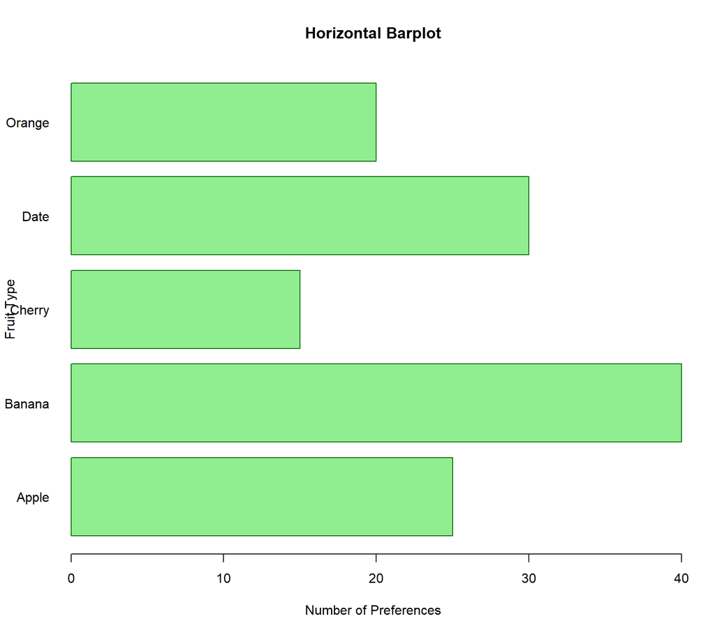

```r
# Horizontal barplot
barplot(frequencies,
        names.arg = categories,
        main = "Horizontal Barplot",
        xlab = "Number of Preferences",
        ylab = "Fruit Type",
        col = "lightgreen",
        border = "darkgreen",
        horiz = TRUE,
        las = 1)
```

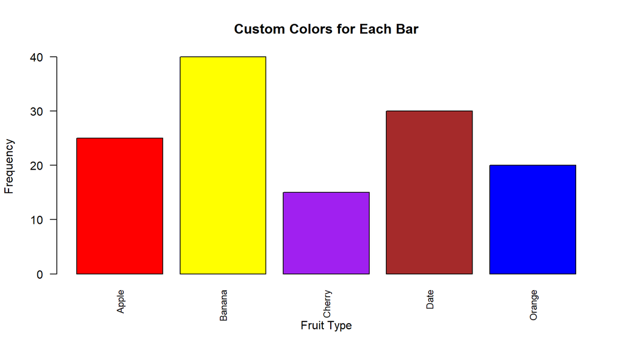

```r
# Customizing bar colors (each bar different)
bar_colors <- c("red", "yellow", "purple", "brown", "blue")

barplot(frequencies,
        names.arg = categories,
        main = "Custom Colors for Each Bar",
        xlab = "Fruit Type",
        ylab = "Frequency",
        col = bar_colors,
        border = "black",
        las = 2,  # Vertical x-axis labels
        cex.names = 0.8)  # Smaller label size
```

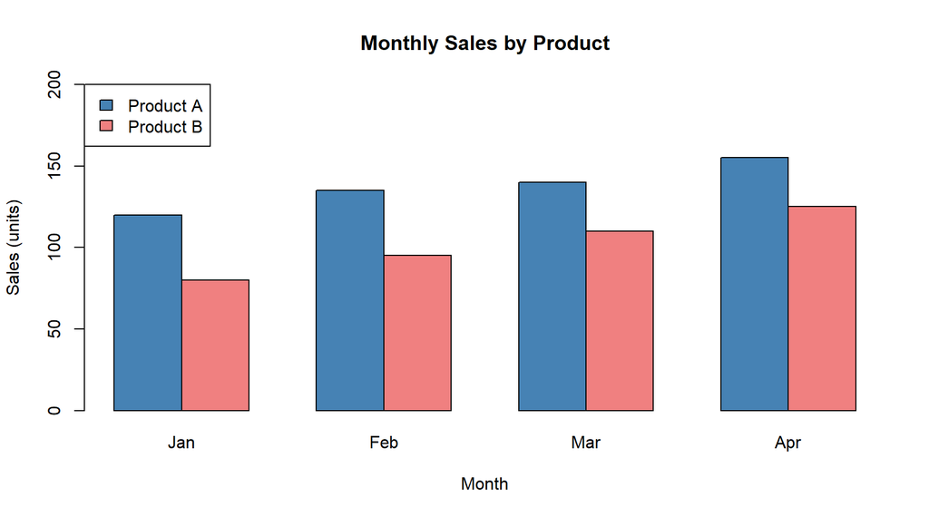

```r
# Grouped barplot (matrix input)
# Create monthly sales data for 2 products
months <- c("Jan", "Feb", "Mar", "Apr")
product_A <- c(120, 135, 140, 155)
product_B <- c(80, 95, 110, 125)
sales_matrix <- rbind(product_A, product_B)
colnames(sales_matrix) <- months

# Side-by-side bars
barplot(sales_matrix,
        beside = TRUE,
        main = "Monthly Sales by Product",
        xlab = "Month",
        ylab = "Sales (units)",
        col = c("steelblue", "lightcoral"),
        legend.text = c("Product A", "Product B"),
        args.legend = list(x = "topleft"),
        ylim = c(0, 200))
```

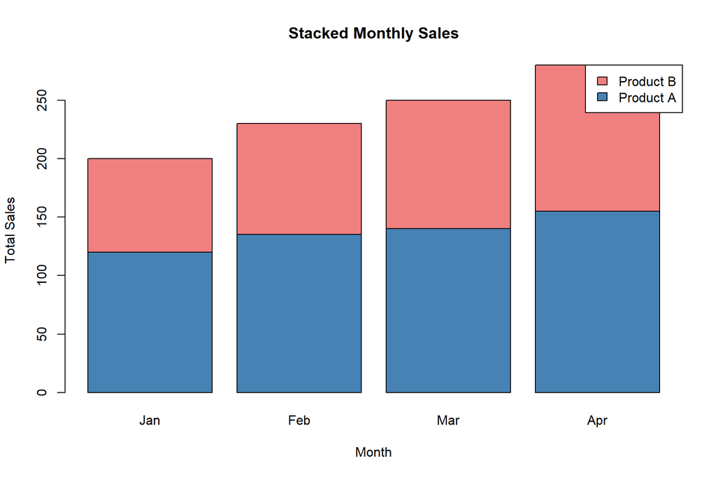

```r
# Stacked barplot
barplot(sales_matrix,
        beside = FALSE,  # Stacked (default for matrix)
        main = "Stacked Monthly Sales",
        xlab = "Month",
        ylab = "Total Sales",
        col = c("steelblue", "lightcoral"),
        legend.text = c("Product A", "Product B"),
        args.legend = list(x = "topright"))
```

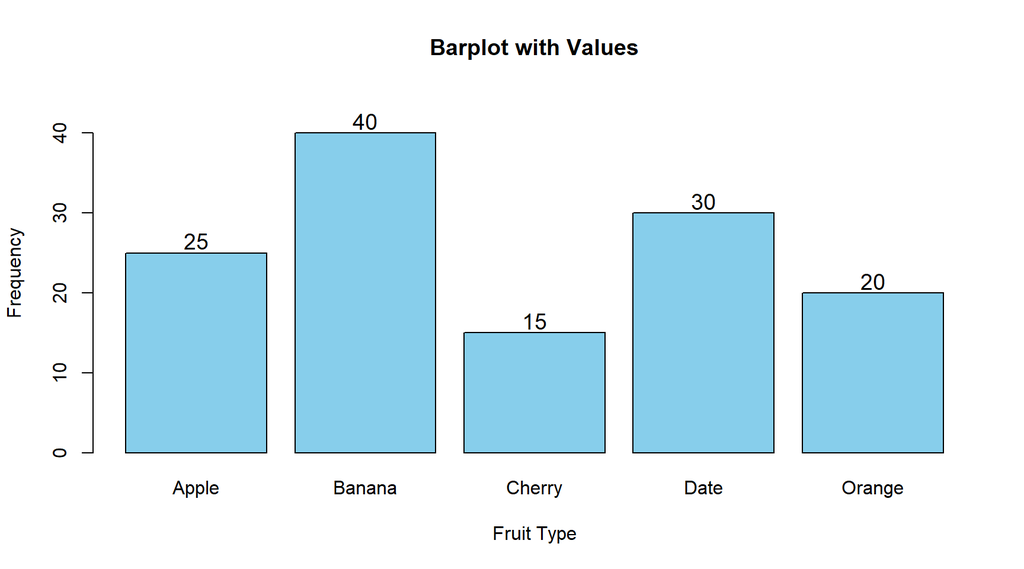

```r
# Adding values on top of bars
bar_plot <- barplot(frequencies,
                    names.arg = categories,
                    main = "Barplot with Values",
                    xlab = "Fruit Type",
                    ylab = "Frequency",
                    col = "skyblue",
                    ylim = c(0, max(frequencies) + 5))

# Add text labels on bars
text(x = bar_plot,
     y = frequencies + 1.5,
     labels = frequencies,
     cex = 1.2)
```

### Quick Reference for `barplot()`:

```
# Single categorical variable
barplot(height = vector_of_values,
        names.arg = labels,
        main = "Title",
        xlab = "X Label",
        ylab = "Y Label",
        col = "color")

# Grouped comparison
barplot(matrix_data,
        beside = TRUE,
        col = c("color1", "color2"),
        legend.text = c("Group1", "Group2"))
```

# The `boxplot()` Function - Box-and-Whisker Plots

**Boxplots** provide a **five-number summary** of data: **minimum**, **first quartile (Q1)**, **median**, **third quartile (Q3)**, and **maximum**. They’re excellent for comparing distributions and identifying **outliers**.

**Anatomy of a Boxplot:**

- Box: Shows IQR (Q1 to Q3)
- Line inside box: Median
- Whiskers: Extend to non-outlier extremes
- Points: Potential outliers

## Basic Syntax

```
boxplot(x)                    # Single vector
boxplot(y ~ group, data = df) # Formula interface (grouped)
```

## Common Arguments

| Argument | Description | Example | Default |
| --- | --- | --- | --- |
| **`x`** | Data values | `df$value` | **Required** |
| `formula` | Group specification | `value ~ group` | `NULL` |
| `data` | Data frame | `df` | `NULL` |
| `col` | Box fill color | `"lightblue"` | `NULL` |
| `horizontal` | Horizontal boxes | `TRUE` | `FALSE` |
| `notch` | Median confidence | `TRUE` | `FALSE` |
| `outcol` | Outlier color | `"red"` | `"black"` |
| `outpch` | Outlier symbol | `16` | `1` |
| `main` | Title | `"Boxplot"` | `NULL` |
| `names` | Group labels | `c("A","B","C")` | `NULL` |

### Examples

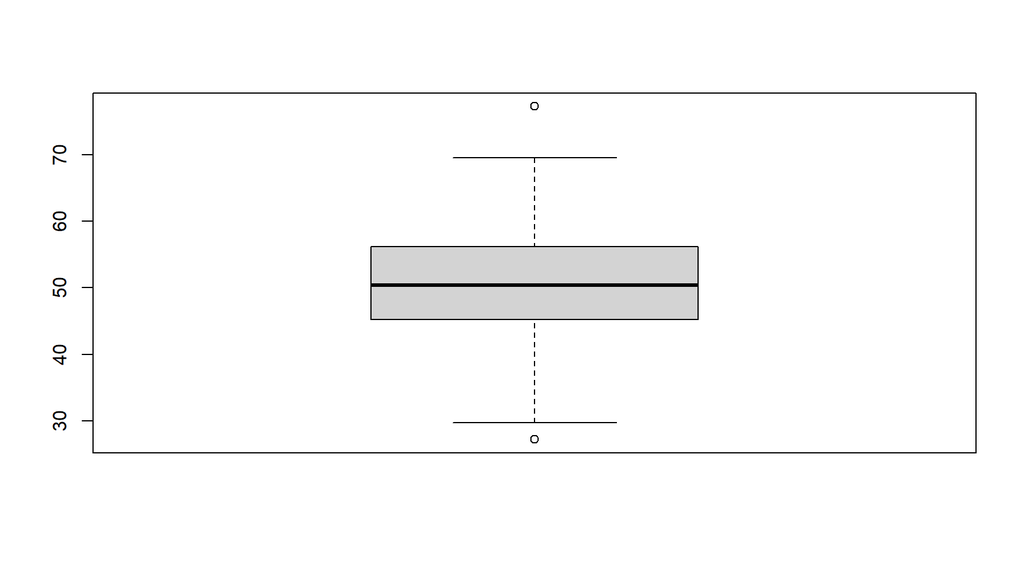

```r
# Basic boxplot (single group)
boxplot(df$value)
```

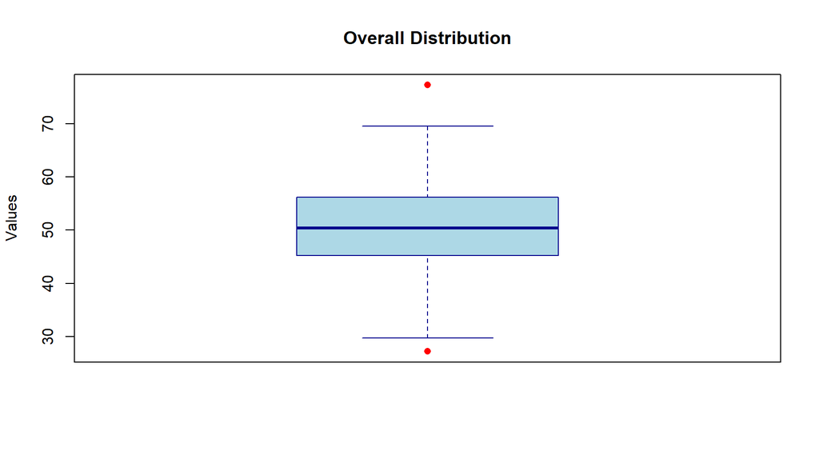

```r
# Enhanced boxplot
boxplot(df$value,
        main = "Overall Distribution",
        ylab = "Values",
        col = "lightblue",
        border = "darkblue",
        outcol = "red",
        outpch = 16)
```

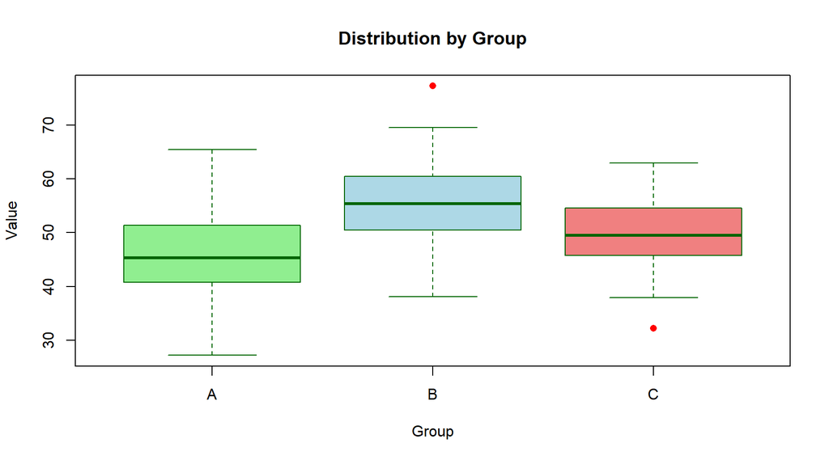

```r
# Grouped boxplots using formula
boxplot(value ~ group, data = df,
        main = "Distribution by Group",
        xlab = "Group",
        ylab = "Value",
        col = c("lightgreen", "lightblue", "lightcoral"),
        border = "darkgreen",
        outcol = "red",
        outpch = 16,
        notch = FALSE)  # Notches show confidence intervals
```

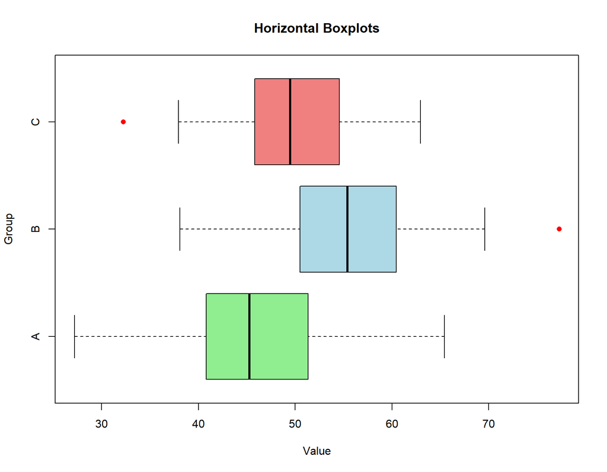

```r
# Horizontal boxplots
boxplot(value ~ group, data = df,
        main = "Horizontal Boxplots",
        xlab = "Value",
        ylab = "Group",
        col = c("lightgreen", "lightblue", "lightcoral"),
        horizontal = TRUE,
        outpch = 16,
        outcol = "red")
```

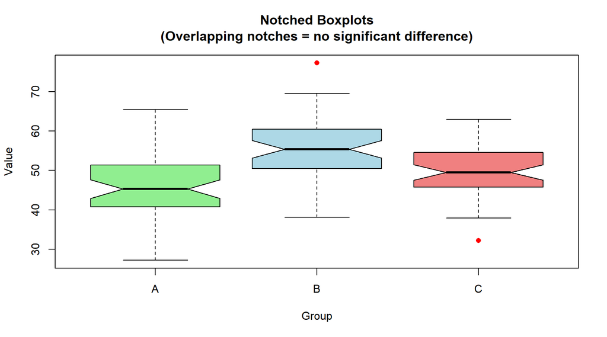

```r
# Notched boxplots (compare medians)
boxplot(value ~ group, data = df,
        main = "Notched Boxplots\n(Overlapping notches = no significant difference)",
        xlab = "Group",
        ylab = "Value",
        col = c("lightgreen", "lightblue", "lightcoral"),
        notch = TRUE,  # Add confidence interval notches
        outpch = 16,
        outcol = "red")
```

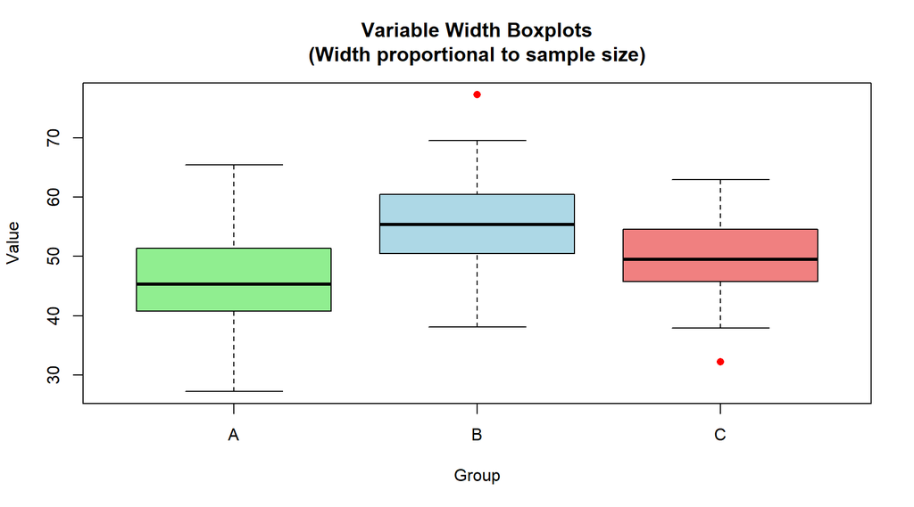

```r
# Boxplots with variable width (proportional to sample size)
boxplot(value ~ group, data = df,
        main = "Variable Width Boxplots\n(Width proportional to sample size)",
        xlab = "Group",
        ylab = "Value",
        col = c("lightgreen", "lightblue", "lightcoral"),
        varwidth = TRUE,
        outpch = 16,
        outcol = "red")
```

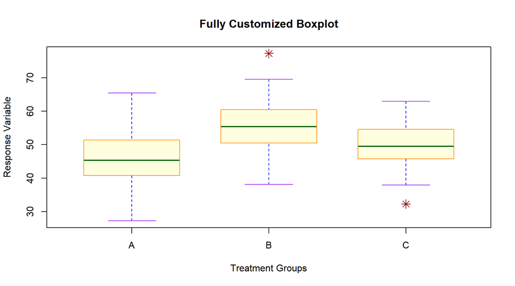

```r
# Customizing boxplot elements
boxplot(value ~ group, data = df,
        main = "Fully Customized Boxplot",
        xlab = "Treatment Groups",
        ylab = "Response Variable",
        col = "lightyellow",
        border = "darkorange",
        outcol = "darkred",
        outpch = 8,  # Asterisk for outliers
        outcex = 1.5,
        medcol = "darkgreen",  # Color of median line
        medlwd = 2,            # Width of median line
        whiskcol = "blue",     # Color of whiskers
        whisklty = 2,          # Dashed whiskers
        staplecol = "purple",  # Color of staples
        boxwex = 0.7)          # Width of boxes
```

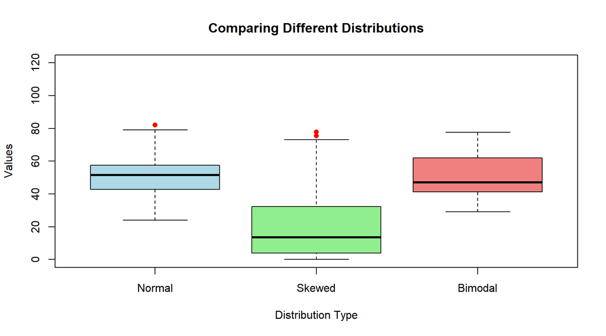

```r
# Multiple boxplots from different data sources
# Create a list of datasets
data_list <- list(
  "Normal" = rnorm(100, mean = 50, sd = 10),
  "Skewed" = rexp(100, rate = 0.05),
  "Bimodal" = c(rnorm(50, 40, 5), rnorm(50, 60, 5))
)

# Boxplot from a list
boxplot(data_list,
        main = "Comparing Different Distributions",
        xlab = "Distribution Type",
        ylab = "Values",
        col = c("lightblue", "lightgreen", "lightcoral"),
        outpch = 16,
        outcol = "red",
        ylim = c(0, 120))
```

### Quick Reference for `boxplot()`:

```
# Single distribution
boxplot(data$variable,
        main = "Title",
        ylab = "Y Label",
        col = "color"
        )

# Multiple groups (formula interface)
boxplot(value ~ group, data = df,
        main = "Title",
        xlab = "Groups",
        ylab = "Values",
        col = c("color1", "color2", "color3")
        )
```

# Combining Multiple Plots

Often you’ll want to display multiple plots in a single figure. Use `par(mfrow = c(rows, cols))`:

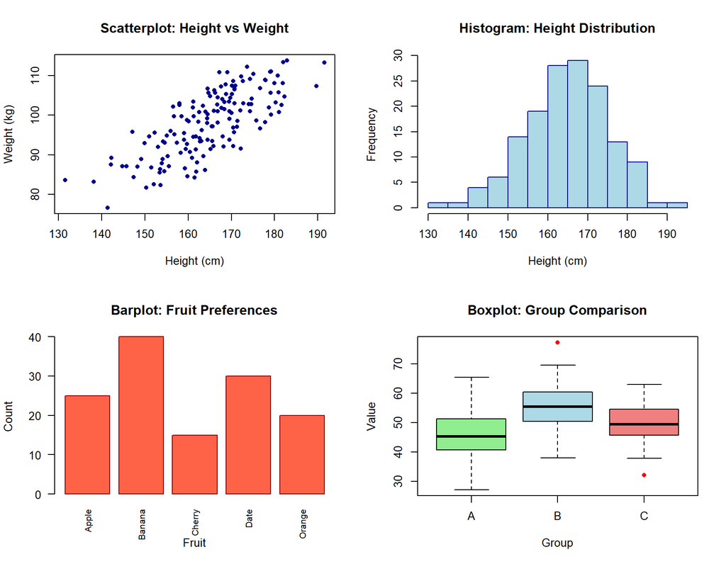

```r
# Set up 2x2 plotting grid
par(mfrow = c(2, 2))

# Plot 1: Scatterplot
plot(df$height, df$weight,
     main = "Scatterplot: Height vs Weight",
     xlab = "Height (cm)", ylab = "Weight (kg)",
     col = "darkblue", pch = 16, cex = 0.8)

# Plot 2: Histogram
hist(df$height,
     main = "Histogram: Height Distribution",
     xlab = "Height (cm)", ylab = "Frequency",
     col = "lightblue", border = "darkblue")

# Plot 3: Barplot
barplot(frequencies,
        names.arg = categories,
        main = "Barplot: Fruit Preferences",
        xlab = "Fruit", ylab = "Count",
        col = "tomato", border = "darkred",
        las = 2, cex.names = 0.8)

# Plot 4: Boxplot
boxplot(value ~ group, data = df,
        main = "Boxplot: Group Comparison",
        xlab = "Group", ylab = "Value",
        col = c("lightgreen", "lightblue", "lightcoral"),
        outpch = 16, outcol = "red")
```

```r
# Reset to single plot
par(mfrow = c(1, 1))
```

# Summary Table

[output not shown]

# Key Summaries

- `plot()` is your go-to for relationships between two numeric variables
- `hist()` reveals the distribution shape of a single variable
- `barplot()` compares categorical data or frequencies
- `boxplot()` shows distribution spread and identifies outliers
- Arguments like `main, xlab, ylab`, and `col` work across all functions
- Use `par(mfrow = c(r, c))` to create multiple plots in one figure
- Save plots with `png(), pdf()`, or `jpeg()` functions before plotting
- Experiment with different arguments - the best way to learn is by doing!

# Quick Decision Guide

**What kind of data do you have?**

- Two continuous variables → Use `plot(x, y)`
  - Example: Height vs Weight, Time vs Temperature
- One continuous variable → Use hist(x)
  - Example: Test scores, Heights, Blood pressure
- Categorical data with counts → Use `barplot()`
  - Example: Survey responses, Sales by product
- Comparing distributions → Use `boxplot(y ~ group)`
  - Example: Treatment vs Control, Different species measurements

# Exercises

## Exercise 1: Scatterplot with `plot()`

- Title: “Random Normal Distribution”
- Blue points, size 1.2
- Type “`b`” (both points and lines)

```r
# Your code here:
```

## Solution

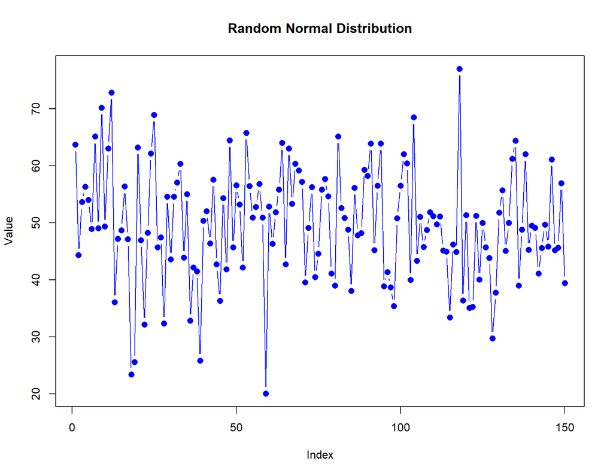

```r
plot(seq_along(normal_data), normal_data,
     main = "Random Normal Distribution",
     xlab = "Index",
     ylab = "Value",
     col = "blue",
     cex = 1.2,
     pch = 16,
     type = "b")
```

## Exercise 2: Histogram with `hist()`

Create a histogram of `skewed_data` with:

- 25 bins
- Title: “Skewed Distribution”
- Green bars with dark green borders
- Add a vertical line at the median

```r
# Your code here:
```

## Solution

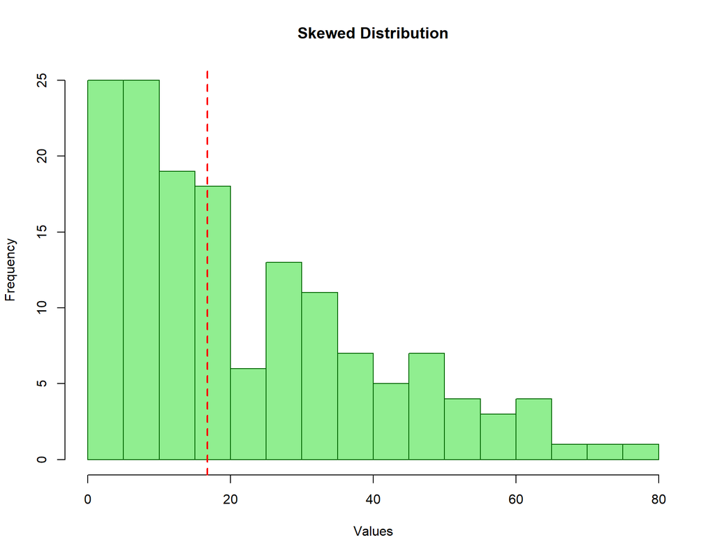

```r
hist(skewed_data,
     breaks = 25,
     main = "Skewed Distribution",
     xlab = "Values", ylab = "Frequency",
     col = "lightgreen", border = "darkgreen")

# Add median line
abline(v = median(skewed_data), col = "red", lwd = 2, lty = 2)
```

## Exercise 3: Barplot with `barplot()`

Create a barplot of monthly sales:

- Months: Jan, Feb, Mar, Apr
- Sales: 150, 220, 180, 250
- Add value labels on top of each bar

```r
# Your code here:
```

## Solution

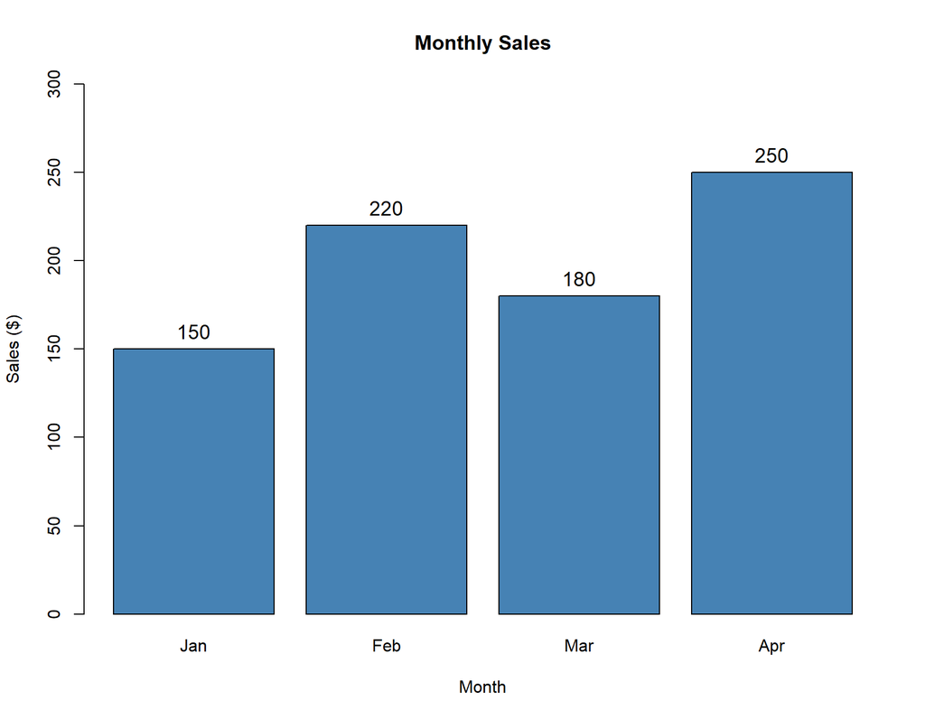

```r
months <- c("Jan", "Feb", "Mar", "Apr")
sales <- c(150, 220, 180, 250)

bp <- barplot(sales,
              names.arg = months,
              main = "Monthly Sales",
              xlab = "Month", ylab = "Sales ($)",
              col = "steelblue",
              ylim = c(0, 300))

text(x = bp, y = sales + 10, labels = sales, cex = 1.2)
```

## Exercise 4: Boxplot with `boxplot()`

Create a boxplot comparing `group_A`, `group_B`, and `group_C` with:

- Title: “Group Comparison”
- Colors: lightblue, lightgreen, lightcoral
- Horizontal orientation
- Add a notch

```r
# Your code here:
```

## Solution

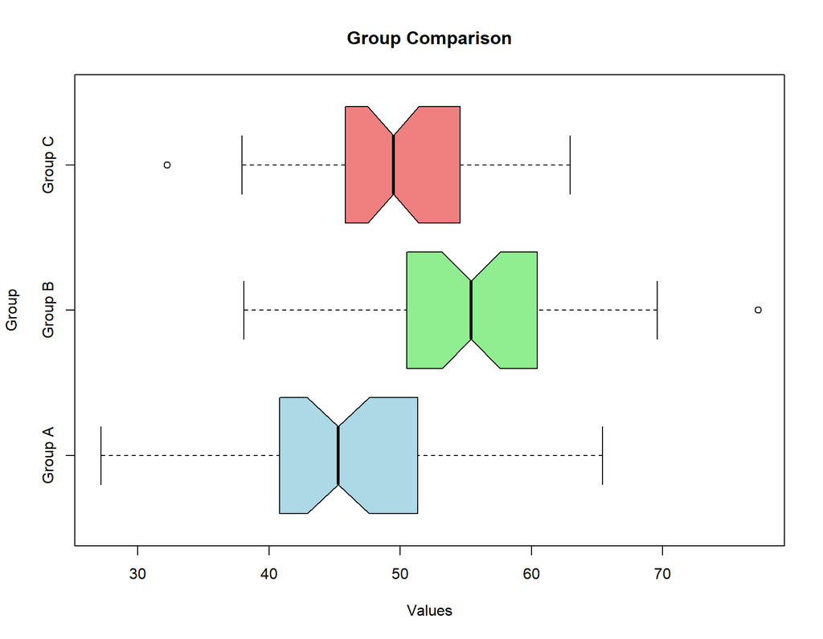

```r
boxplot(group_A, group_B, group_C,
        main = "Group Comparison",
        xlab = "Values", ylab = "Group",
        col = c("lightblue", "lightgreen", "lightcoral"),
        horizontal = TRUE,
        notch = TRUE,
        names = c("Group A", "Group B", "Group C"))
```